# Modeling and prediction for movies

## Setup

### Load packages

```r
library(knitr)
library(ggplot2)
library(colorspace)
library(tidyr)
library(dplyr)
```

### Load data

Make sure your data and R Markdown files are in the same directory. When loaded your data file will be called `movies`. Delete this note when before you submit your work.

```r
load("movies.Rdata")
```

## Part 1: Data

IMDb(Internet Movie Database) is an online database of information related to films, television programs, home videos, video games, and streaming content online – including cast, production crew and personal biographies, plot summaries, trivia, fan and critical reviews, and ratings. Most data in the database is provided by volunteer contributors. The registration process is necessary to contribute information to the site.Users are also invited to rate any film on a scale of 1 to 10, and the totals are converted into a weighted mean-rating that is displayed beside each title, with online filters employed to deter ballot-stuffing.

Rotten Tomatoes is an American review-aggregation website for film and television. For function critic aggregate score, Rotten Tomatoes staff first collect online reviews from writers who are certified members of various writing guilds or film critic-associations.To be accepted as a critic on the website, a critic’s original reviews must garner a specific number of “likes” from users. Those classified as “Top Critics” generally write for major newspapers. The critics upload their reviews to the movie page on the website, and need to mark their review “fresh” if it’s generally favorable or “rotten” otherwise. It is necessary for the critic to do so as some reviews are qualitative and do not grant a numeric score, making it impossible for the system to be automatic. For function audience score and reviews, each movie features a “user average”, which calculates the percentage of registered users who have rated the film positively on a 5-star scale, similar to calculation of recognized critics’ reviews.

Generabizability: Both of the two datasets collect data from their registrators who are younger and familiar with the internet. The view from elder people are not considered. Causality: The datas are collected from anoymous survey so they are randomly assigned.

## Part 2: Research question

For different types of films, is the audience score associated with the critics_score?

Relevance: Whether or not that for different types of the films, how the critics_scores fits with the audience score.

## Part 3: Exploratory data analysis

```r
q <- select(movies, title_type, audience_score, critics_score)

docu <- q %>%
     filter(title_type == "Documentary")

docuLine <- lm(audience_score ~ critics_score, data = docu)

summary(docuLine)
```

```
##
## Call:
## lm(formula = audience_score ~ critics_score, data = docu)
##
## Residuals:
##     Min      1Q  Median      3Q     Max
## -17.274  -5.578   1.619   5.673  11.441
##
## Coefficients:
##               Estimate Std. Error t value Pr(>|t|)
## (Intercept)   67.41976    7.15196   9.427 6.36e-13 ***
## critics_score  0.17854    0.07987   2.235   0.0296 *
## ---
## Signif. codes:  0 '***' 0.001 '**' 0.01 '*' 0.05 '.' 0.1 ' ' 1
##
## Residual standard error: 7.295 on 53 degrees of freedom
## Multiple R-squared:  0.08615,    Adjusted R-squared:  0.06891
## F-statistic: 4.997 on 1 and 53 DF,  p-value: 0.02964
```

```r
featureF <- q %>%
     filter(title_type == "Feature Film")

FFLine <- lm(audience_score ~ critics_score, data = featureF)

summary(FFLine)
```

```
##
## Call:
## lm(formula = audience_score ~ critics_score, data = featureF)
##
## Residuals:
##     Min      1Q  Median      3Q     Max
## -36.214 -10.265   0.517  10.446  43.199
##
## Coefficients:
##               Estimate Std. Error t value Pr(>|t|)
## (Intercept)   34.04976    1.33502   25.50   <2e-16 ***
## critics_score  0.48220    0.02175   22.17   <2e-16 ***
## ---
## Signif. codes:  0 '***' 0.001 '**' 0.01 '*' 0.05 '.' 0.1 ' ' 1
##
## Residual standard error: 14.65 on 589 degrees of freedom
## Multiple R-squared:  0.455,  Adjusted R-squared:  0.454
## F-statistic: 491.7 on 1 and 589 DF,  p-value: < 2.2e-16
```

```r
TVM <- q %>%
     filter(title_type == "TV Movie")

TVMLine <- lm(audience_score ~ critics_score, data = TVM)

summary(TVMLine)
```

```
##
## Call:
## lm(formula = audience_score ~ critics_score, data = TVM)
##
## Residuals:
##       1       2       3       4       5
##  26.374   6.767  -2.585 -14.150 -16.406
##
## Coefficients:
##               Estimate Std. Error t value Pr(>|t|)
## (Intercept)     4.4565    20.2913   0.220   0.8403
## critics_score   0.8695     0.3020   2.879   0.0636 .
## ---
## Signif. codes:  0 '***' 0.001 '**' 0.01 '*' 0.05 '.' 0.1 ' ' 1
##
## Residual standard error: 20.14 on 3 degrees of freedom
## Multiple R-squared:  0.7342, Adjusted R-squared:  0.6456
## F-statistic: 8.288 on 1 and 3 DF,  p-value: 0.06359
```

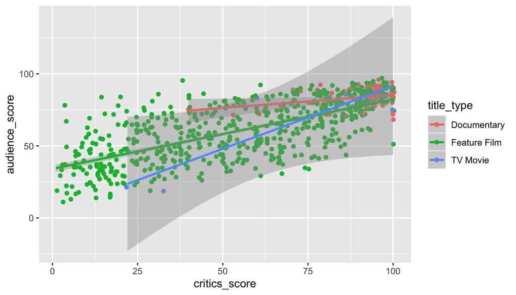

```r
ggplot(data = movies, aes(x = critics_score,colour = title_type , y = audience_score)) +
     geom_jitter() +
     geom_smooth(method = "lm")
```

From the analysis, the slope of the documentary is the smallest. The slope of the TV movie is the largest.

This can be seen on the plot clearly. The line of documentary is nearly horizontal, but the line of TV movie is much more cliffy.

From the plot and the analysis, the audience scores will be more dependent on the critics scores for TV movies rather than the documentaries.

## Part 4: Modeling

```r
library(MASS)
q4 <- lm(audience_score ~ critics_rating +genre + critics_rating + audience_rating + mpaa_rating +  dvd_rel_year + dvd_rel_month + dvd_rel_day + best_pic_win+best_actor_win + best_actress_win + best_dir_win + top200_box+ runtime + thtr_rel_year + thtr_rel_month + thtr_rel_day + imdb_rating + imdb_num_votes, data = movies)

stepAIC(q4, direction = "backward")
```

```
## Start:  AIC=2510.99
## audience_score ~ critics_rating + genre + critics_rating + audience_rating +
##     mpaa_rating + dvd_rel_year + dvd_rel_month + dvd_rel_day +
##     best_pic_win + best_actor_win + best_actress_win + best_dir_win +
##     top200_box + runtime + thtr_rel_year + thtr_rel_month + thtr_rel_day +
##     imdb_rating + imdb_num_votes
##
##                    Df Sum of Sq   RSS    AIC
## - mpaa_rating       5     124.3 29065 2503.8
## - thtr_rel_day      1       0.0 28940 2509.0
## - best_pic_win      1       0.1 28940 2509.0
## - thtr_rel_year     1       0.1 28940 2509.0
## - best_dir_win      1       0.4 28941 2509.0
## - dvd_rel_month     1       0.4 28941 2509.0
## - best_actor_win    1       1.9 28942 2509.0
## - top200_box        1      10.7 28951 2509.2
## - critics_rating    2     129.3 29070 2509.9
## - genre            10     898.4 29839 2510.6
## - runtime           1      82.7 29023 2510.8
## - best_actress_win  1      85.9 29026 2510.9
## - dvd_rel_day       1      87.6 29028 2510.9
## <none>                          28940 2511.0
## - thtr_rel_month    1      94.9 29035 2511.1
## - imdb_num_votes    1     125.5 29066 2511.8
## - dvd_rel_year      1     188.0 29128 2513.2
## - imdb_rating       1   22011.5 50952 2872.1
## - audience_rating   1   28756.9 57697 2952.0
##
## Step:  AIC=2503.75
## audience_score ~ critics_rating + genre + audience_rating + dvd_rel_year +
##     dvd_rel_month + dvd_rel_day + best_pic_win + best_actor_win +
##     best_actress_win + best_dir_win + top200_box + runtime +
##     thtr_rel_year + thtr_rel_month + thtr_rel_day + imdb_rating +
##     imdb_num_votes
##
##                    Df Sum of Sq   RSS    AIC
## - best_dir_win      1       0.1 29065 2501.8
## - dvd_rel_month     1       0.2 29065 2501.8
## - thtr_rel_day      1       0.2 29065 2501.8
## - best_pic_win      1       0.5 29065 2501.8
```

[output cut: 182 more lines]

```
##
## Step:  AIC=2488.85
## audience_score ~ genre + audience_rating + dvd_rel_year + dvd_rel_day +
##     runtime + thtr_rel_month + imdb_rating + imdb_num_votes
##
##                   Df Sum of Sq   RSS    AIC
## <none>                         29296 2488.8
## - dvd_rel_day      1     105.0 29401 2489.1
## - thtr_rel_month   1     109.6 29406 2489.2
## - imdb_num_votes   1     119.8 29416 2489.5
## - runtime          1     125.0 29422 2489.6
## - dvd_rel_year     1     274.8 29571 2492.8
## - genre           10    1211.5 30508 2494.9
## - imdb_rating      1   27913.8 57210 2916.5
## - audience_rating  1   30756.6 60053 2947.7
```

```
##
## Call:
## lm(formula = audience_score ~ genre + audience_rating + dvd_rel_year +
##     dvd_rel_day + runtime + thtr_rel_month + imdb_rating + imdb_num_votes,
##     data = movies)
##
## Coefficients:
##                    (Intercept)                  genreAnimation
##                      2.902e+02                       3.886e+00
## genreArt House & International                     genreComedy
##                     -2.170e+00                       1.567e+00
##               genreDocumentary                      genreDrama
##                      1.397e+00                      -3.023e-01
##                    genreHorror  genreMusical & Performing Arts
##                     -1.603e+00                       3.762e+00
##        genreMystery & Suspense                      genreOther
##                     -2.975e+00                       3.522e-01
## genreScience Fiction & Fantasy          audience_ratingUpright
##                      2.782e-01                       2.008e+01
##                   dvd_rel_year                     dvd_rel_day
##                     -1.490e-01                      -4.606e-02
##                        runtime                  thtr_rel_month
##                     -2.660e-02                      -1.202e-01
##                    imdb_rating                  imdb_num_votes
##                      9.764e+00                       4.595e-06
```

From the backward selection, the selected variables are : genre, audience_rating, dvd_rel_year, dvd_rel_day, runtime, thtr_rel_month, imdb_rating, imdb_num_votes.

Exclude certain variables because the AIC are smaller than we need.

Because a lot of variables seem to associate with the audience_scores, I choose the backward selection to make it quicker to find the needed variables.

```r
seleLine <- lm(formula = audience_score ~ genre + audience_rating + dvd_rel_year +
     dvd_rel_day + runtime + thtr_rel_month + imdb_rating + imdb_num_votes,
     data = movies)

 summary(seleLine)
```

```
##
## Call:
## lm(formula = audience_score ~ genre + audience_rating + dvd_rel_year +
##     dvd_rel_day + runtime + thtr_rel_month + imdb_rating + imdb_num_votes,
##     data = movies)
##
## Residuals:
##      Min       1Q   Median       3Q      Max
## -22.3071  -4.6149   0.4888   4.4130  24.7439
##
## Coefficients:
##                                  Estimate Std. Error t value Pr(>|t|)
## (Intercept)                     2.902e+02  1.238e+02   2.345   0.0194 *
## genreAnimation                  3.886e+00  2.475e+00   1.570   0.1169
## genreArt House & International -2.170e+00  2.139e+00  -1.014   0.3109
## genreComedy                     1.567e+00  1.143e+00   1.371   0.1708
## genreDocumentary                1.397e+00  1.500e+00   0.931   0.3520
## genreDrama                     -3.023e-01  9.912e-01  -0.305   0.7605
## genreHorror                    -1.603e+00  1.686e+00  -0.951   0.3420
## genreMusical & Performing Arts  3.762e+00  2.237e+00   1.682   0.0932 .
## genreMystery & Suspense        -2.975e+00  1.261e+00  -2.359   0.0186 *
## genreOther                      3.522e-01  1.934e+00   0.182   0.8555
## genreScience Fiction & Fantasy  2.782e-01  2.576e+00   0.108   0.9140
## audience_ratingUpright          2.008e+01  7.846e-01  25.595   <2e-16 ***
## dvd_rel_year                   -1.490e-01  6.160e-02  -2.419   0.0158 *
## dvd_rel_day                    -4.606e-02  3.081e-02  -1.495   0.1354
## runtime                        -2.660e-02  1.630e-02  -1.632   0.1032
## thtr_rel_month                 -1.202e-01  7.869e-02  -1.528   0.1271
## imdb_rating                     9.764e+00  4.004e-01  24.383   <2e-16 ***
## imdb_num_votes                  4.595e-06  2.877e-06   1.597   0.1108
## ---
## Signif. codes:  0 '***' 0.001 '**' 0.01 '*' 0.05 '.' 0.1 ' ' 1
##
## Residual standard error: 6.852 on 624 degrees of freedom
##   (9 observations deleted due to missingness)
## Multiple R-squared:  0.8874, Adjusted R-squared:  0.8843
## F-statistic: 289.2 on 17 and 624 DF,  p-value: < 2.2e-16
```

## Part 5: Prediction

```r
predict(seleLine, newdata = data.frame(genre="Action & Adventure", audience_rating="Upright", dvd_rel_year=2016, dvd_rel_day=7, runtime=108, thtr_rel_month=3, imdb_rating=8.0,imdb_num_votes=406188),interval = "confidence")
```

```
##        fit      lwr      upr
## 1 86.25876 83.42942 89.08809
```